# Prediction Algorithm using Network Statistics

### Graph

The graph created here shows the connections between nodes where they met with someone of the same race.

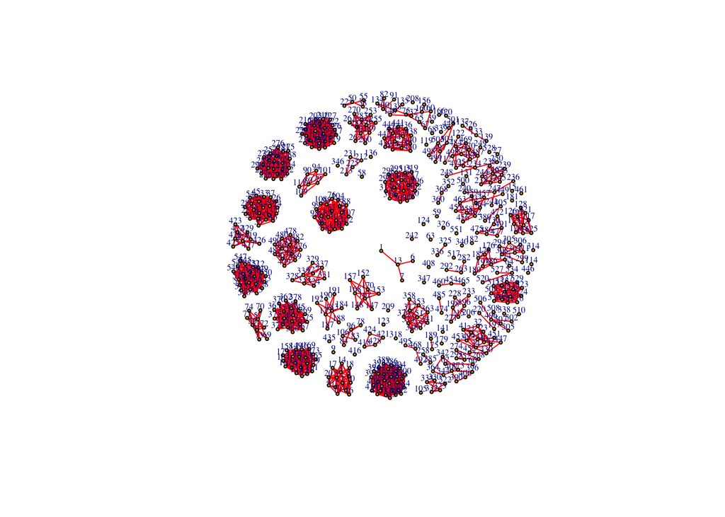

The number of nodes in each component was recorded and assigned to the respective nodes in the data set.

```r
> compDF = data.frame(components(g)$membership)
> compTableDF = data.frame(table(components(g)$membership))
> nameMatchVar = setNames(as.character(compTableDF$Freq), compTableDF$Var1)
> totalCompDF = data.frame(lapply(compDF, function(i) nameMatchVar[i]))
> componentTotalNodes = totalCompDF$components.g..membership
> dat2$componentNumber = compDF$components.g..membership
> averageAge = aggregate(age ~ componentNumber, data=dat2, mean)
> nameMatchVar2 = setNames(as.character(averageAge$age), averageAge$componentNumber)
> averageAgeDF = data.frame(lapply(compDF, function(i) nameMatchVar2[i]))
> averageAgeOfComponent = averageAgeDF$components.g..membership
> percentOfMales = aggregate(gender ~ componentNumber, data=dat2, mean)
> nameMatchVar3 = setNames(as.character(percentOfMales$gender), percentOfMales$componentNumber)
> percentOfMalesDF = data.frame(lapply(compDF, function(i) nameMatchVar3[i]))
> percentOfMalesInComponent = percentOfMalesDF$components.g..membership
> averageImprace = aggregate(imprace ~ componentNumber, data=dat2, mean)
> nameMatchVar4 = setNames(as.character(averageImprace$imprace), averageImprace$componentNumber)
> averageImpraceDF = data.frame(lapply(compDF, function(i) nameMatchVar4[i]))
> averageImpraceOfComponent = averageImpraceDF$components.g..membership
> averageSports = aggregate(sports ~ componentNumber, data=dat2, mean)
> nameMatchVar5 = setNames(as.character(averageSports$sports), averageSports$componentNumber)
> averageSportsDF = data.frame(lapply(compDF, function(i) nameMatchVar5[i]))
> averageSportsOfComponent = averageSportsDF$components.g..membership
> averageTvsports = aggregate(tvsports ~ componentNumber, data=dat2, mean)
> nameMatchVar6 = setNames(as.character(averageTvsports$tvsports), averageTvsports$componentNumber)
> averageTvsportsDF = data.frame(lapply(compDF, function(i) nameMatchVar6[i]))
> averageTvsportsOfComponent = averageTvsportsDF$components.g..membership
> averageExercise = aggregate(exercise ~ componentNumber, data=dat2, mean)
> nameMatchVar7 = setNames(as.character(averageExercise$exercise), averageExercise$componentNumber)
> averageExerciseDF = data.frame(lapply(compDF, function(i) nameMatchVar7[i]))
> averageExerciseOfComponent = averageExerciseDF$components.g..membership
> averageDining = aggregate(dining ~ componentNumber, data=dat2, mean)
> nameMatchVar8 = setNames(as.character(averageDining$dining), averageDining$componentNumber)
> averageDiningDF = data.frame(lapply(compDF, function(i) nameMatchVar8[i]))
> averageDiningOfComponent = averageDiningDF$components.g..membership
> averageMuseums = aggregate(museums ~ componentNumber, data=dat2, mean)
> nameMatchVar9 = setNames(as.character(averageMuseums$museums), averageMuseums$componentNumber)
> averageMuseumsDF = data.frame(lapply(compDF, function(i) nameMatchVar9[i]))
> averageMuseumsOfComponent = averageMuseumsDF$components.g..membership
> averageHiking = aggregate(hiking ~ componentNumber, data=dat2, mean)
> nameMatchVar10 = setNames(as.character(averageHiking$hiking), averageHiking$componentNumber)
> averageHikingDF = data.frame(lapply(compDF, function(i) nameMatchVar10[i]))
> averageHikingOfComponent = averageHikingDF$components.g..membership
> averageGaming = aggregate(gaming ~ componentNumber, data=dat2, mean)
> nameMatchVar11 = setNames(as.character(averageGaming$gaming), averageGaming$componentNumber)
> averageGamingDF = data.frame(lapply(compDF, function(i) nameMatchVar11[i]))
> averageGamingOfComponent = averageGamingDF$components.g..membership
> averageClubbing = aggregate(clubbing ~ componentNumber, data=dat2, mean)
> nameMatchVar12 = setNames(as.character(averageClubbing$clubbing), averageClubbing$componentNumber)
> averageClubbingDF = data.frame(lapply(compDF, function(i) nameMatchVar12[i]))
> averageClubbingOfComponent = averageClubbingDF$components.g..membership
> averageReading = aggregate(reading ~ componentNumber, data=dat2, mean)
> nameMatchVar13 = setNames(as.character(averageReading$reading), averageReading$componentNumber)
> averageReadingDF = data.frame(lapply(compDF, function(i) nameMatchVar13[i]))
> averageReadingOfComponent = averageReadingDF$components.g..membership
> averageTv = aggregate(tv ~ componentNumber, data=dat2, mean)
> nameMatchVar14 = setNames(as.character(averageTv$tv), averageTv$componentNumber)
> averageTvDF = data.frame(lapply(compDF, function(i) nameMatchVar14[i]))
> averageTvOfComponent = averageTvDF$components.g..membership
> averageTheater = aggregate(theater ~ componentNumber, data=dat2, mean)
> nameMatchVar15 = setNames(as.character(averageTheater$theater), averageTheater$componentNumber)
> averageTheaterDF = data.frame(lapply(compDF, function(i) nameMatchVar15[i]))
> averageTheaterOfComponent = averageTheaterDF$components.g..membership
> averageMovies = aggregate(movies ~ componentNumber, data=dat2, mean)
> nameMatchVar16 = setNames(as.character(averageMovies$movies), averageMovies$componentNumber)
> averageMoviesDF = data.frame(lapply(compDF, function(i) nameMatchVar16[i]))
> averageMoviesOfComponent = averageMoviesDF$components.g..membership
> averageConcerts = aggregate(concerts ~ componentNumber, data=dat2, mean)
> nameMatchVar17 = setNames(as.character(averageConcerts$concerts), averageConcerts$componentNumber)
> averageConcertsDF = data.frame(lapply(compDF, function(i) nameMatchVar17[i]))
> averageConcertsOfComponent = averageConcertsDF$components.g..membership
> averageMusic = aggregate(music ~ componentNumber, data=dat2, mean)
> nameMatchVar18 = setNames(as.character(averageMusic$music), averageMusic$componentNumber)
> averageMusicDF = data.frame(lapply(compDF, function(i) nameMatchVar18[i]))
> averageMusicOfComponent = averageMusicDF$components.g..membership
> averageShopping = aggregate(shopping ~ componentNumber, data=dat2, mean)
> nameMatchVar19 = setNames(as.character(averageShopping$shopping), averageShopping$componentNumber)
> averageShoppingDF = data.frame(lapply(compDF, function(i) nameMatchVar19[i]))
> averageShoppingOfComponent = averageShoppingDF$components.g..membership
> averageYoga = aggregate(yoga ~ componentNumber, data=dat2, mean)
> nameMatchVar20 = setNames(as.character(averageYoga$yoga), averageYoga$componentNumber)
> averageYogaDF = data.frame(lapply(compDF, function(i) nameMatchVar20[i]))
> averageYogaOfComponent = averageYogaDF$components.g..membership
>
> # change to numeric
> dat2$componentTotalNodes = as.numeric(paste(componentTotalNodes))
> dat2$averageAgeOfComponent = round(as.numeric(paste(averageAgeOfComponent)))
> dat2$percentOfMalesInComponent = round(as.numeric(paste(percentOfMalesInComponent)),3)
> dat2$averageImpraceOfComponent = round(as.numeric(paste(averageImpraceOfComponent)),3)
> dat2$averageSportsOfComponent = round(as.numeric(paste(averageSportsOfComponent)),3)
> dat2$averageTvsportsOfComponent = round(as.numeric(paste(averageTvsportsOfComponent)),3)
> dat2$averageExerciseOfComponent = round(as.numeric(paste(averageExerciseOfComponent)),3)
> dat2$averageDiningOfComponent = round(as.numeric(paste(averageDiningOfComponent)),3)
> dat2$averageMuseumsOfComponent = round(as.numeric(paste(averageMuseumsOfComponent)),3)
> dat2$averageHikingOfComponent = round(as.numeric(paste(averageHikingOfComponent)),3)
> dat2$averageGamingOfComponent = round(as.numeric(paste(averageGamingOfComponent)),3)
> dat2$averageClubbingOfComponent = round(as.numeric(paste(averageClubbingOfComponent)),3)
> dat2$averageReadingOfComponent = round(as.numeric(paste(averageReadingOfComponent)),3)
> dat2$averageTvOfComponent = round(as.numeric(paste(averageTvOfComponent)),3)
> dat2$averageTheaterOfComponent = round(as.numeric(paste(averageTheaterOfComponent)),3)
> dat2$averageMoviesOfComponent = round(as.numeric(paste(averageMoviesOfComponent)),3)
> dat2$averageConcertsOfComponent = round(as.numeric(paste(averageConcertsOfComponent)),3)
> dat2$averageMusicOfComponent = round(as.numeric(paste(averageMusicOfComponent)),3)
> dat2$averageShoppingOfComponent = round(as.numeric(paste(averageShoppingOfComponent)),3)
> dat2$averageYogaOfComponent = round(as.numeric(paste(averageYogaOfComponent)),3)
```

A seed was set so that this report would stay consistent. Testing was done without setting a seed.

```r
> set.seed(231)
```

The data was split into training and test data with a 4:1 ratio.

```r
> # get test and training sets
> splits = split_data(dat2, frac=c(4,1))
> tr_data = splits[[1]]
> te_data = splits[[2]]
```

### Predictions using Logistic Regression

This particular model was made using age, gender, imprace, sports, exercise, gaming, clubbing, and tv as predictors to determine if they had a successful match. Imprace rated on a scale from 1-10 on how important it is that they date someone of the same race. The activites used as features after imprace indicate how interested an individual is in those activities

```r
> fit = glm(hasMatch ~ age + gender + imprace + sports + exercise + gaming + clubbing + tv, data=tr_data, family=binomial)
```

Logistic Regression was used here with a threshold of >0.7. A confusion matrix was created to check the accuracy.

```r
> # compute confusion matrix
> y = predict(fit, newdata=te_data, type="response")
> predicts = as.numeric(y > 0.7)
> actuals = te_data$hasMatch
> conf_mtx = table(predicts, actuals)
> conf_mtx
```

```
        actuals
predicts  0  1
       0  2  8
       1 17 84
```

```r
> mean(predicts == actuals)
```

```
[1] 0.7747748
```

```r
> roc_obj = roc(actuals, y)
> auc(roc_obj)
```

```
Area under the curve: 0.5212
```

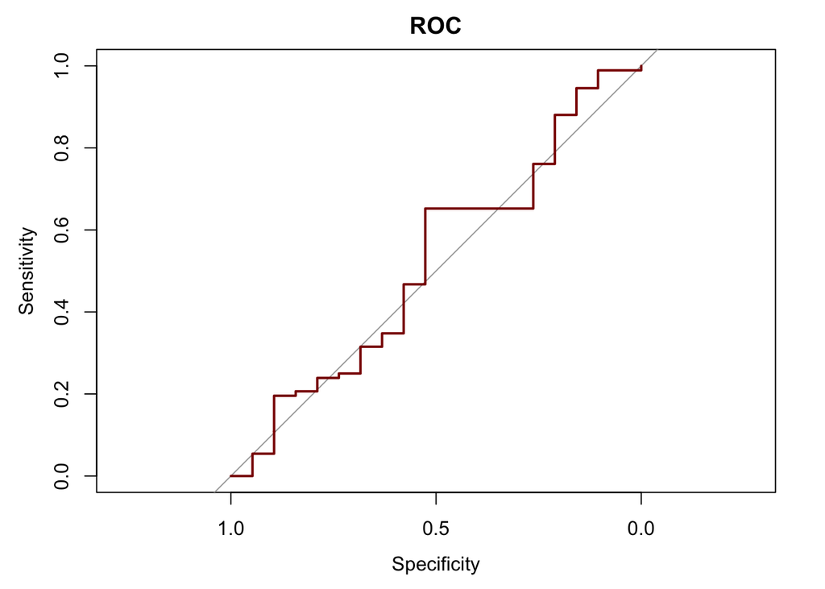

```r
> plot(roc_obj, main="ROC", xlim=c(1,0), ylim=c(0,1), col="red4")
```

```r
> fit2 = glm(hasMatch ~ averageAgeOfComponent + percentOfMalesInComponent + averageImpraceOfComponent + averageSportsOfComponent + averageExerciseOfComponent + averageGamingOfComponent + averageClubbingOfComponent + averageTvOfComponent + componentTotalNodes, data=tr_data, family=binomial)
```

Logistic Regression was used here as well with the same threshold.

```r
> # compute confusion matrix
> y2 = predict(fit2, newdata=te_data, type="response")
> predicts = as.numeric(y2 > 0.7)
> actuals = te_data$hasMatch
> conf_mtx = table(predicts, actuals)
> conf_mtx
```

```
        actuals
predicts  0  1
       0  4  7
       1 15 85
```

```r
> mean(predicts == actuals)
```

```
[1] 0.8018018
```

```r
> roc_obj2 = roc(actuals, y2)
> auc(roc_obj2)
```

```
Area under the curve: 0.611
```

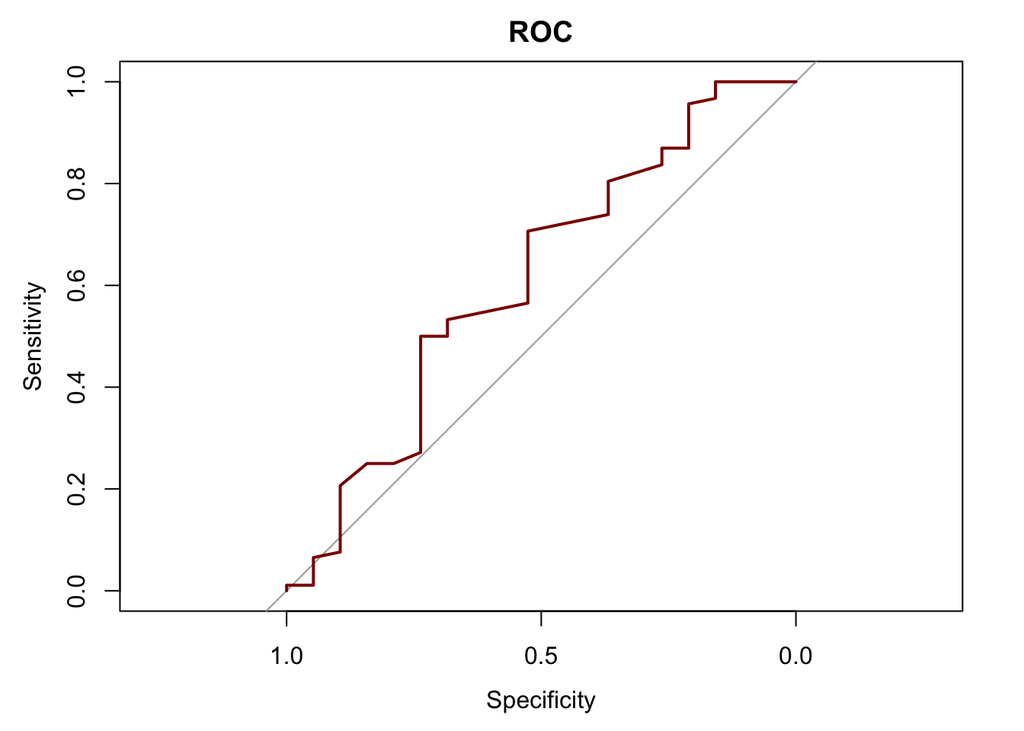

```r
> plot(roc_obj2, main="ROC", xlim=c(1,0), ylim=c(0,1), col="red4")
```

### Predictions using Classification Trees

We tried to make predictions using the same predictors that were used in the Logistic Regression predictions.

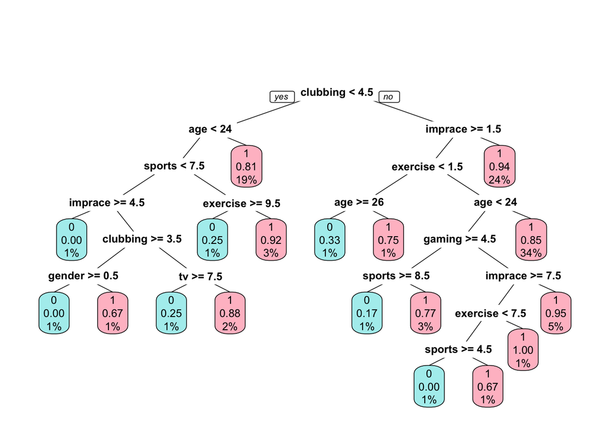

```r
> fit = rpart(hasMatch ~ age + gender + imprace + sports + exercise + gaming + clubbing + tv, dat = tr_data, method = "class", control=rpart.control(minsplit=5, minbucket=3, cp=0.01))
> prp(fit, extra=106, varlen= 0,faclen=0, main = "", box.col = c("paleturquoise", "pink")[fit$frame$yval])
```

This is the accuracy for the Classification Tree using node attributes.

```r
> predicted = predict(fit, te_data, type = "class")
> actual = te_data$hasMatch
> table(actual, predicted)
```

```
      predicted
actual  0  1
     0  1 18
     1  5 87
```

```r
> mean(actual == predicted)
```

```
[1] 0.7927928
```

The AUC of this model is terrible and under .50.

```r
> roc_obj = roc(actual, as.numeric(predicted) - 1)
> auc(roc_obj)
```

```
Area under the curve: 0.4991
```

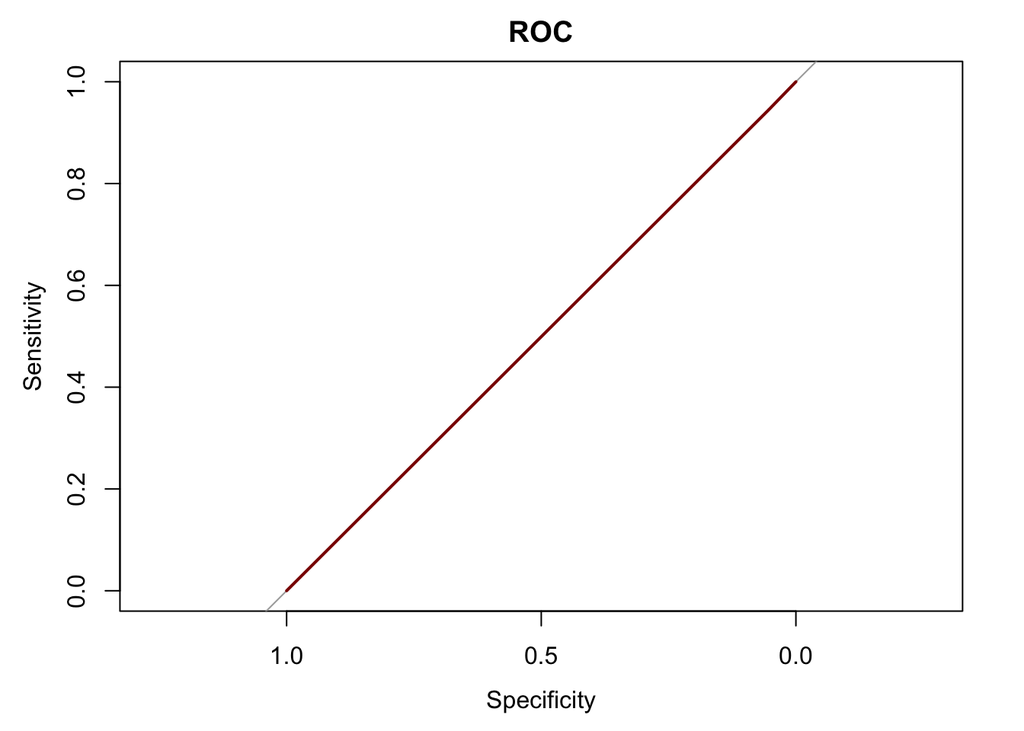

```r
> plot(roc_obj, main="ROC", xlim=c(1,0), ylim=c(0,1), col="red4")
```

This is the second Classification Tree that uses graph component aggregates.

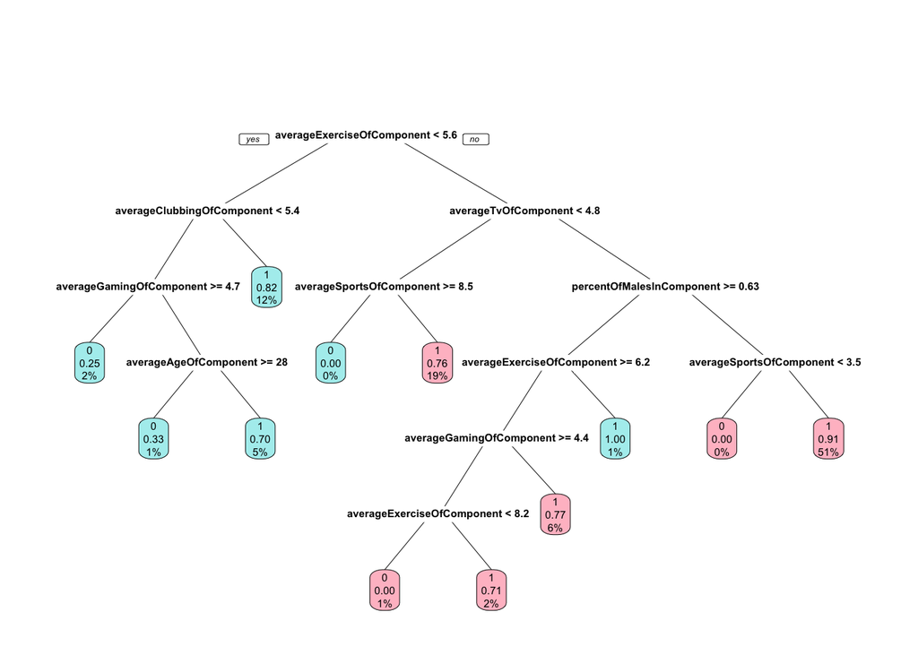

```r
> fit2 = rpart(hasMatch ~ averageAgeOfComponent + percentOfMalesInComponent + averageImpraceOfComponent + averageSportsOfComponent + averageExerciseOfComponent + averageGamingOfComponent + averageClubbingOfComponent + averageTvOfComponent + componentTotalNodes, dat = tr_data, method = "class", control=rpart.control(minsplit=1, minbucket=1, cp=0.01))
> prp(fit2, extra=106, varlen= 0,faclen=0, main = "", box.col = c("paleturquoise", "pink")[fit$frame$yval])
```

```r
> predicted = predict(fit2, te_data, type = "class")
> actual = te_data$hasMatch
> table(actual, predicted)
```

```
      predicted
actual  0  1
     0  3 16
     1  4 88
```

```r
> mean(actual == predicted)
```

```
[1] 0.8198198
```

The AUC for this model is also fairly poor as it is under .60.

```r
> roc_obj2 = roc(actual, as.numeric(predicted) - 1)
> auc(roc_obj2)
```

```
Area under the curve: 0.5572
```

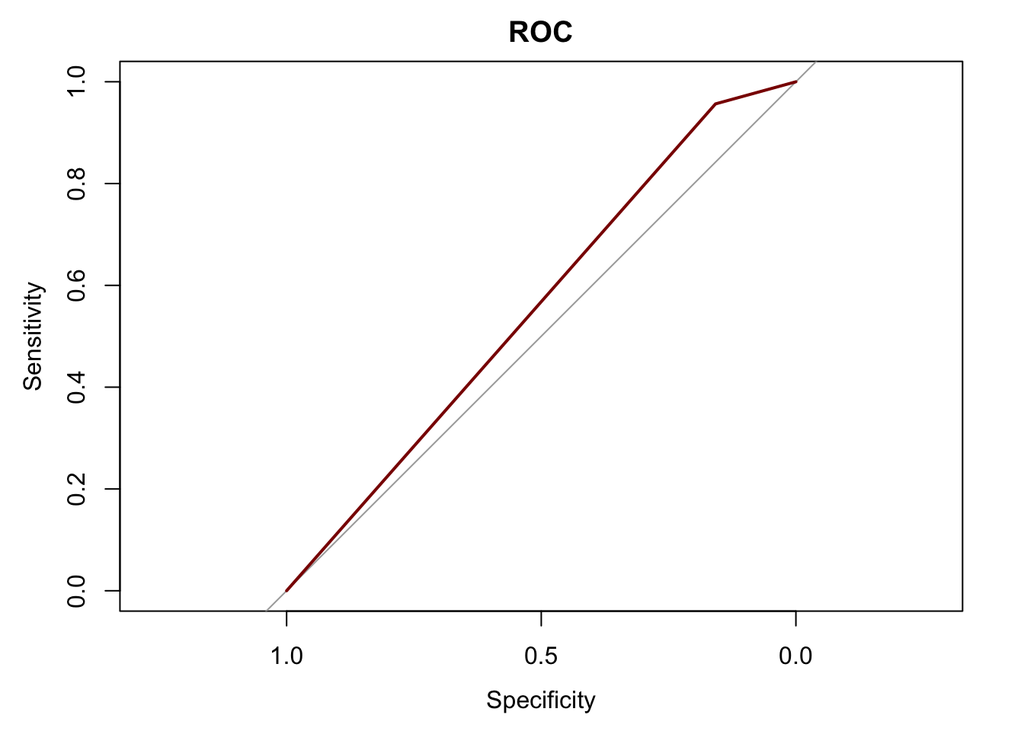

```r
> plot(roc_obj2, main="ROC", xlim=c(1,0), ylim=c(0,1), col="red4")
```

### Conclusion

From what could be seen, the AUC for the prediction that uses graph component aggregates appears to be commonly higher in the case of Logistic Regression. This has been tested with a couple of different seeds and there were only a couple of occurrances where the AUC for using node information instead of graph aggregates had a higher AUC. There are also many more features that can be used when creating these models. Classification Trees were not very effective when making predictions however that can be because of this particular data set. This shows that using the AUC has a higher potential of being more accurate and effective in making predictions when using Logistic Regression.